# Capítulo 3

## Creación de la base de datos

### Procedencia de los datos

Los datos han sido extraídos de la web oficial de la Real Federación Española de Voleibol [1], en la que podemos encontrar estadísticas de todas las competiciones profesionales, tanto masculinas como femeninas, del voleibol español.

Se han recogido los datos de la Liga Iberdola de la temporada 2020/2021. Es conocida con ese nombre por motivos de patrocinio pero se refiere a la Superliga Femenina de Voleibol, es decir, la liga femenina de voleibol de máxima categoría en España. Nació en 1970, organizada por la Real Federación Española de Voleibol. El sistema de competición para determinar su posición en la clasificación consiste en dos vueltas en las que se enfrentan todos contra todos. Una vez terminada esa fase regular, los cuatro primeros equipos de la clasificación se vuelven a enfrentar en una eliminatoria al mejor de cinco partidos donde finalmente se proclama un ganador.

En la página correspondiente a la Liga Iberdola de la temporada 2020/2021, dentro del apartado *Estadísticas* se ha seleccionado *Detalles por equipos*. De cada equipo, se han utilizado solo los datos acerca de cada partido jugado (no se han utilizado los datos totales ni en porcentaje), de forma que por cada equipo tenemos 22 registros que corresponden a los 22 encuentros en los que han participado.

[figure not shown]

Tabla con las estadísticas del equipo FC Cartagena - Algar Surmenor

Los datos se han extraído mediante el portapapeles utilizando *Excel*, creando un archivo con formato .*xlsx* llamado *Partidos_20_21.xlsx*. Luego, hemos obtenido una base de datos con 264 registros y 26 variables.

### Modificaciones en la base de datos

En esta misma hoja de cálculo, hemos realizado las siguientes modificaciones:

- La primera columna de nuestra base de datos se corresponde con los equipos que han participado en el encuentro (*ejemplo: “FC Cartagena - Algar Surmenor — Madrid Chamberí”*) . Como de cada partido nos interesan las estadísticas por separado de cada equipo, hemos modificado la variable renombrándola como **Equipo**. En cada registro entonces se hace referencia al equipo del que hemos extraído las datos correspondientes.
- Se ha añadido una variable que nos será muy relevante en nuestro estudio. A esta variable la llamaremos **Ganado/Perdido** y nos indica con un 0 o un 1 si el equipo correspondiente a ese registro ha perdido o ganado ese partido, respectivamente.
- Hemos renombrado las variables correspondientes a cada acción técnica, con el fin de evitar confusión entre variables con nombres iguales o similares. De esta forma, se ha añadido el nombre de la acción a la que se refiere la variable al principio de cada una de ellas (*ejemplo: “Saque-Tot,”“Recep-Tot”*).
- Se ha encontrado un error en el registro número 245, en las estadísticas de “Sanaya Libby’s La Laguna” correspondientes al partido contra “Osacc Haro Rioja Voley.” La columna “Tot” es el resultado de sumar las columnas “Saque-Pts” , “Ataque-Exc” y “Bloqueo-Pts.” El valor de “Tot” para ese registro es 51 que no coincide con la suma de los valores correspondientes (4 + 35 + 13). Finalmente, buscando en la pestaña *Encuentros* en la web [1] el partido “Sanaya Libby’s La Laguna — Osacc Haro Rioja Voley” hemos encontrado la ficha de *DataVolley* en la que el valor de “Bloqueo-Pts” no coincide con el valor anterior. De esta forma, los valores para las columnas “Tot” y “Bloqueo-Pts” se han cambiado por `50` y `11` respectivamente.

Finalmente, queda una base de datos formada por 264 registros con 27 variables que describen las estadísticas correspondientes a todos los encuentros jugados durante esa temporada.

## Descripción de las variables

### Breve descripción de las acciones técnicas

Para poder introducir las variables necesitamos saber cuáles son las principales acciones técnicas del voleibol, que se recogen en [2]:

- Saque: acción de poner en juego el balón por el jugador zaguero derecho situado en la zona de saque, es decir, uno de los atacantes de detrás de la linea de 3 metros que divide la zona de ataque delantera.
- Recepción: interceptar y controlar un balón dirigiéndolo hacia otro compañero en buenas condiciones para poder jugarlo. Los balones bajos se reciben con los antebrazos unidos al frente a la altura de la cintura y los altos con los dedos, por encima de la cabeza.
- Ataque: toda acción de dirigir el balón al campo del adversario, excepto el saque y el bloqueo, se considera golpe de ataque.
- Bloqueo: acción de los jugadores cerca de la red encaminada a interceptar el balón que procede del campo contrario por encima del borde superior de la red. Sólo los delanteros pueden completar un bloqueo. Está prohibido bloquear el saque adversario.

### Variables del estudio

En este estudio se ha trabajado con 18 variables, que se han seleccionado a través del **software Rstudio**, al igual que el resto de modificaciones que se han llevado a cabo con el resto datos. Las variables estudiadas son las siguientes:

- Equipo: equipo al que corresponden las estadísticas extraídas de la base de datos para ese partido.
- Sets jugados: número de sets que se han jugado en el partido. Un partido de voleibol se juega al mejor de 5 sets y un equipo gana un set cuando llega a un total de 25 puntos con una ventaja de 2 puntos con respecto a los del equipo contrario. El quinto set se juega a 15 puntos.
- BP: (break-point) puntos que se consiguen cuando el equipo está sacando, es decir, manteniendo el saque.
- G: puntos conseguidos cuando el saque ha correspondido al equipo contrario.
- Saque-Tot: número de saques totales realizados durante el partido.
- Saque-Pts: puntos totales conseguidos con un saque directo, es decir, aquél saque en el que el balón cae directamente en el campo del equipo contrario.
- Saque-Err: número de saques fallados.
- Recep-Tot: número de recepciones totales realizadas durante el partido.
- Recep-Err: número total de errores en las recepciones durante el partido.
- Recep-Neg: número de recepciones “negativas” entendiéndose por “negativas” aquellas en las que el balón va a la zona verde del campo.
- Recep-Exc: número de recepciones perfectas, aquellas en las que se dirige el balón a la zona roja (zona donde se encuentra el colocador para realizar el segundo toque), de forma que sea más fácil construir una jugada.
- Ataque-Tot: número de acciones de ataque realizadas durante el partido.
- Ataque-Err: número total de errores en ataques (mandados fuera del campo o que no han pasado la red) durante el partido.
- Ataque-Blo: número total de ataques que han sido bloqueados durante el partido.
- Ataque-Exc: número de puntos que se han conseguido con un ataque durante el partido.
- Bloqueo-Red: número de acciones de bloqueo en las que se ha tocado la red.
- Bloqueo-Pts: puntos conseguidos por el bloqueo durante el partido.

## Modelos de predicción

### Análisis de los datos

#### Valores atípicos (outliers)

Mediante gráficos de caja y bigotes, utilizando la función *boxplot()*, observamos que hay “valores atípicos” en algunas de las variables. En las variables *Recep-Err*, *Saque-Err*, *Ataque-Blo* o *Recep-Neg*, estos valores indican que ha habido muchos fallos en acciones técnicas durante el partido. Esto puede indicarnos que la probabilidad de que los equipos hayan perdido esos partidos es mayor.

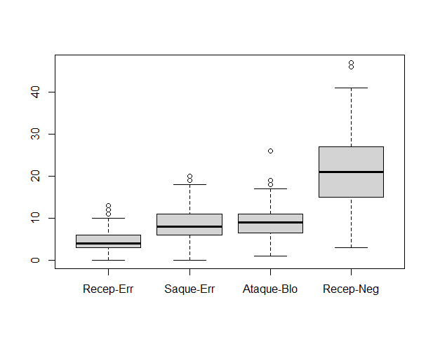

Boxplot variables 1

En cambio, en variables como *Saque-Pts*, *Bloqueo-Pts* o *Recep-Exc*, que los valores sean mayores también pueden ayudarnos a distinguir si se ha ganado o no el partido.

[figure not shown]

[1]

2020. Real federación española de voleibol.

[2]

Quintana, J. 2010. Principales técnicas de voleibol.